# In-term I, M362M Fall 2020

The first two problems are computational. Submit their solutions in pdf (knitted from Rmd) just like you submit your HW. The third problem is theoretical - do not use R for it. You can submit your solutions either typed up as a pdf, or hand-written and then scanned. If you have any questions, please post them on Piazza.

## Problem 1

1. Find the beta distribution in R’s help system. The only thing you need to know about it is that it comes with two positive parameters $\alpha$ and $\beta$ (called `shape1` and `shape2` in R). Simulate $n=10000$ draws from the beta distribution with parameters $\alpha=0.5$ and $\beta=0.3$. Plot a density histogram of your simulations as well as the pdf of the underlying distribution on the same plot. (Note: if you use the command `lines` instead of `plot` for the pdf, it will be automatically added to your previous plot - the histogram, in this case).
2. Let $X$ be a beta-distributed random variable with parameters $\alpha=0.5$ and $\beta=0.3$ (as above), and let $Y$ be an independent random variable with the same distribution. Estimate the probability ${\mathbb{P}}[ XY > 1+ \log(Y)]$. Check graphically whether $XY$ and $1+\log(Y)$ are independent random variables.
3. Let $X$, $Y$ and $Z$ be three independent random variables uniformly distributed on $(0,1)$, and let $M = \min(X,Y,Z)$. A theorem in probability states that $M$ has a beta distribution with some parameters $\alpha$ and $\beta$. Use simulation (and associated plots) to make an educated guess about what the values of $\alpha$ and $\beta$ are. (Hint: they are nice round numbers.)

1.

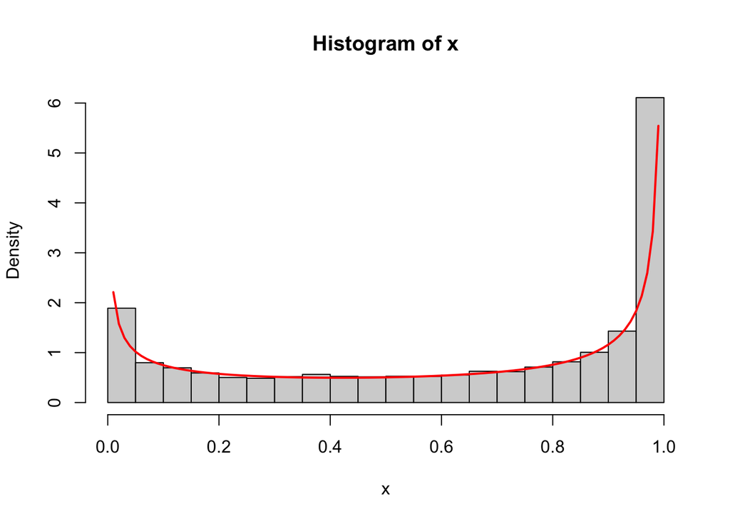

```r
x = rbeta(10000, shape1 = 0.5, shape2 = 0.3)
hist(x, probability = T)
x_pdf = seq(0, 1, by = 0.01)
y_pdf = dbeta(x_pdf, 0.5, 0.3)
lines(x_pdf,
      y_pdf,
      type = "l",
      col = "red",
      lwd = 2)
```

2.

We use Monte Carlo to estimate the probability:

```r
x = rbeta(10000, shape1 = 0.5, shape2 = 0.3)
y = rbeta(10000, shape1 = 0.5, shape2 = 0.3)
z = x * y > 1 + log(y)
mean(z)
```

```
## [1] 0.4457
```

and the permuation test to check for (in)dependence

[figure not shown]

```r
w = x * y
z = 1 + log(y)
par(mfrow = c(2, 2))
z_perm_1 = sample(z)
z_perm_2 = sample(z)
z_perm_3 = sample(z)
plot(w, z)
plot(w, z_perm_1)
plot(w, z_perm_2)
```

3.

First, we simulate $10,000$ draws from the distribution of $M$. The function `min` is not vectorized (and it should not be!), so we cannot simply write $m = min(x,y,z)$. Luckily there is another function, called `pmin` (where `p` stands for parallel) which returns the component-wise min. Alternatively, we could use the function `apply` to apply `min` to each row of the data frame `df` which contains the simulations of $X,Y$ and $Z$:

```r
nsim = 10000
x = runif(nsim)
y = runif(nsim)
z = runif(nsim)
m = pmin(x, y, z)
# or, alternatively,
df = data.frame(x, y, z)
m = apply(df, 1, min)
```

The idea is to compare the histogram of (the simulations) of $M$ to pdfs of the beta distributions for various values of parameters and see what fits best. The function `try_parameters` below does exacly that - it superimposes the beta pdf onto the histogram of `m` (just like in part 1. above). We try a few different values, and finally settle on $\alpha=1$ and $\beta=3$, because it seems to fit will. It turns out that $\alpha=1$ and $\beta=3$ is, indeed, correct.

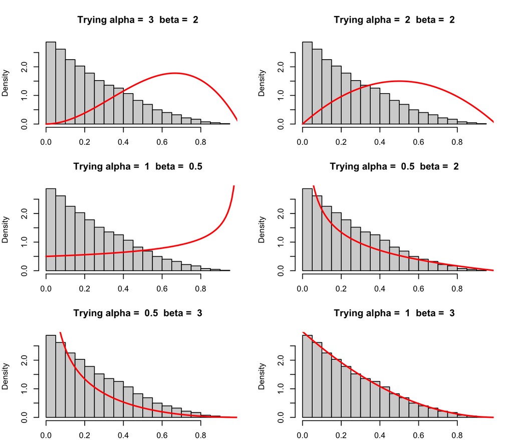

```r
try_parameters = function (alpha, beta) {
  hist(m,
       probability = T,
       main = paste("Trying alpha = ", alpha, " beta = ", beta))
  x_pdf = seq(0, 1, by = 0.01)
  y_pdf = dbeta(x_pdf, alpha, beta)
  lines(x_pdf,
        y_pdf,
        type = "l",
        col = "red",
        lwd = 2)
}

par(mfrow = c(3, 2))
try_parameters(3, 2)
try_parameters(2, 2)
try_parameters(1, 0.5)
try_parameters(0.5, 2)
try_parameters(0.5, 3)
try_parameters(1, 3)
```

Alternatively, you could have looked up the mean and the variance of the beta distribution online, and obtained the following expressions:
$$\text{ mean}= \frac{\alpha}{\alpha+\beta}, \text{ variance} = \frac{\alpha\beta}{(\alpha+\beta)^2 (\alpha+\beta+1)},$$
and then tried to find $\alpha$ and $\beta$ to match the estimated mean and variance

```r
c(mean(m), var(m))
```

```
## [1] 0.24952292 0.03719576
```

## Problem 2

Harry Potter’s cousin Nigel Potter owns a magical set of three dice. They behave just like any three (fair, independent) 6-sided dice, except for the fact that, when thrown together, they always show three *distinct* numbers. In other words, the outcomes with repeating numbers never happen, while all combinations of three distinct numbers are equally likely.

1. Create a large ($\ge 10,000$) set of simulations of throws of these magical dice. Use any method you like.
2. Output the contingency table for the outcomes of the first two dice, and compare to theoretical probabilities.
3. Draw samples from the conditional distribution of the outcome of the third die, given that the sum on the first two is $6$. Display the contingency table for your outcomes.
4. (Extra credit) Find the (theoretical) conditional distribution of the third die given that the sum on the first two is $6$, and compare it to your result from 3. above.

1.

Here are three different methods you can use to do this problem:

*Sampling without replacement:*

The three magical dice sample *without* replacement from the set $\{1,2,3,4,5,6\}$, so we can simply do the following:

```r
nsim = 10000
sims = data.frame(
  t(replicate(nsim, sample(c(1,2,3,4,5,6), size=3, replace = FALSE)))
  )
colnames(sims) = c("x","y","z")
```

*The rejection method:*

We simulate three regular dice, and then simply reject all outcomes where two of the numbers are the same:

```r
nsim = 25000
x0 = sample(c(1,2,3,4,5,6), size= nsim, replace = TRUE)
y0 = sample(c(1,2,3,4,5,6), size= nsim, replace = TRUE)
z0 = sample(c(1,2,3,4,5,6), size= nsim, replace = TRUE)

good = (x0 != y0) & (y0 != z0) & (x0 != z0)

sims = data.frame(x = x0[good],
                  y = y0[good],
                  z = z0[good]
                  )
nsim = dim(sims)[1] # we rejected a random number of draws
```

*Using `sample`:*

We need to make the list of all allowed combinations (no repeats) and then sample the entire triplet of dice at once. I am using `rbind` to append a row to a data frame, but you can do this in many other ways.

```r
nsim = 100000
df = data.frame()
for (i in 1:6) {
  for (j in 1:6) {
    for (k in 1:6) {
      if ( (i != j) & (j != k) & (i != k) ) {
        df = rbind(df, c(i,j,k) )
    }}}}
colnames(df) = c("x","y","z")

rows = as.numeric(row.names(df)) # as.numeric needed to turn strings into integers
sampled_rows = sample(rows, nsim, replace = TRUE)

sims = df[sampled_rows,]
```

2. The probability of seeing a pair $(i,j)$ is $0$ if $i=j$ and $1/30$ otherwise (where $30$ is the number of pairs of different numbers).

```r
table_sim = table(sims$x, sims$y)/nsim
table_th = matrix(1/30, ncol = 6, nrow = 6 )
for (i in 1:6)
  table_th[ i , i ]=0
(error = table_sim-table_th)
```

```
##
##             1         2         3         4         5         6
##   1  0.000000 -0.000063 -0.000373 -0.000653  0.000197 -0.000343
##   2  0.000467  0.000000 -0.000023  0.000057  0.000447 -0.000083
##   3 -0.000383 -0.000603  0.000000  0.000197  0.000437  0.000227
##   4  0.000077 -0.000943  0.000457  0.000000 -0.000573  0.000717
##   5  0.000067  0.000047 -0.000553 -0.000463  0.000000 -0.000013
##   6  0.001337 -0.000563 -0.000103  0.001057 -0.000043  0.000000
```

3.

```r
good = (sims$x + sims$y == 6)
z_cond = sims$z[good]
(table_sim = table(z_cond)/length(z_cond))
```

```
## z_cond
##    1    2    3    4    5    6
## 0.12 0.13 0.26 0.12 0.13 0.24
```

4.

We can reuse the code from above (simulation using `sample`) to list all possible elementary outcomes with $x+y=6$ and then count the frequencies of different values of the third die in this list (or we could simply do that on a piece of paper):

```r
df = data.frame()
for (i in 1:6) {
  for (j in 1:6) {
    for (k in 1:6) {
      if ( (i != j) & (j != k) & (i != k) & (i+j == 6)) {
        df = rbind(df, c(i,j,k) )
      }
    }
  }
}
colnames(df) = c("x","y","z")
(table_th= table(df$z)/length(df$z))
```

```
##
##    1    2    3    4    5    6
## 0.12 0.12 0.25 0.12 0.12 0.25
```

The error is given by:

```r
options(digits=2)
(error = table_sim - table_th)
```

```
## z_cond
##        1        2        3        4        5        6
## -0.00037  0.00129  0.00544 -0.00074  0.00046 -0.00608
```

## Problem 3

Let $X$ be a simple symmetric random walk ($p=0.5$). Compute the following

1. ${\mathbb{P}}[ X_{24}=12 | X_8 = 6]$.
2. ${\mathbb{P}}[ X_1\cdot X_2 \cdot X_3 > 0]$ (this is the product of $X_1$, $X_2$ and $X_3$).
3. The standard deviation of $X_1+X_2+X_3$.
4. ${\mathbb{P}}[ X_{10}=2 \text{ and } X_{17} > 2]$

1.

As in Problem 3.8.3, we have
$${\mathbb{P}}[ X_{24}=12 | X_8 = 6] = {\mathbb{P}}[ X_{24} - X_8 = 12 -6 ]=
{\mathbb{P}}[ X_{16} = 6] = \binom{16}{11} 2^{-16}.$$

2.

The only trajectories that have the required property are $(0,1,2,3)$ and $(0,1,2,1)$ so the probability is $2 \times 1/8 = 1/4$.

3.

We write $X_1+X_2+X_3 = 3 \delta_1 + 2 \delta_2 + \delta_3$. Since the $\delta$s are independent and each each has variance $1$, we have
$$\begin{align}
\operatorname{sd} (X_1+X_2+X_3)&= \sqrt{ \operatorname{Var}[ X_1+X_2+X_3]} =
\sqrt{ \operatorname{Var}[3 \delta_1] + \operatorname{Var}[2 \delta_2] + \operatorname{Var}[\delta_3]}\\
& =\sqrt{ 9 + 4 + 1} = \sqrt{14}.
\end{align}$$

4. We have
$${\mathbb{P}}[ X_{10}=2 \text{ and } X_{17} > 2] = {\mathbb{P}}[ X_{17} > 2 | X_{10} = 2] \times {\mathbb{P}}[X_{10} = 2]$$
By the formula from the notes, ${\mathbb{P}}[ X_{10} = 2] = \binom{10}{6} 2^{-10}$. As in Problem 3.8.3, ${\mathbb{P}}[X_{17} > 2 | X_{10} = 2] = {\mathbb{P}}[ X_{7}>0]$. Since $X_7$ is symmetric around $0$, and it *cannot* take the value $0$, we must have ${\mathbb{P}}[X_7>0] = {\mathbb{P}}[X_7 < 0] = 1/2$. Therefore
$${\mathbb{P}}[ X_{10}=2 \text{ and } X_{17} > 2] = \binom{10}{6} 2^{-11}.$$